# 质量安全相关岗位招聘和薪酬水平

## 总述

本次采集有效数据7391条（城市发布量>=100），主要分析质量相关岗位招聘和薪酬，如质量工程师、体系工程师、质检员、供应商质量工程师、品质经理或主管等，我们将分析如下方面：

- 01.城市分布：上海占16%，平均月薪10383元；深圳占14%，平均月薪8387元；苏州占10%，平均月薪8171元；广州占9%，平均月薪7597元；其余城市均在6%或以下。
- 02.行业分布：机械/设备占18%，平均月薪8029元；电子技术/半导体占12%，平均月薪7718元；汽车占9%,平均月薪9327元；原材料/加工占6%，平均月薪7986元。
- 03.公司规模：1000人以下占86%，平均月薪8159元；1000-5000人占11%，平均月薪9487元。
- 04.公司类型：民企占66%，平均月薪7987元；外企占18%，平均月薪9026元。
- 05.工作经验：5年以下占87%，平均月薪7580元；5-10年占12%，平均月薪12709元。
- 06.学历要求：大专占47%，平均月薪8349元；本科占19%，平均月薪12154元。

## 01.城市分布

[figure not shown]

roadmap

## 02.行业分布

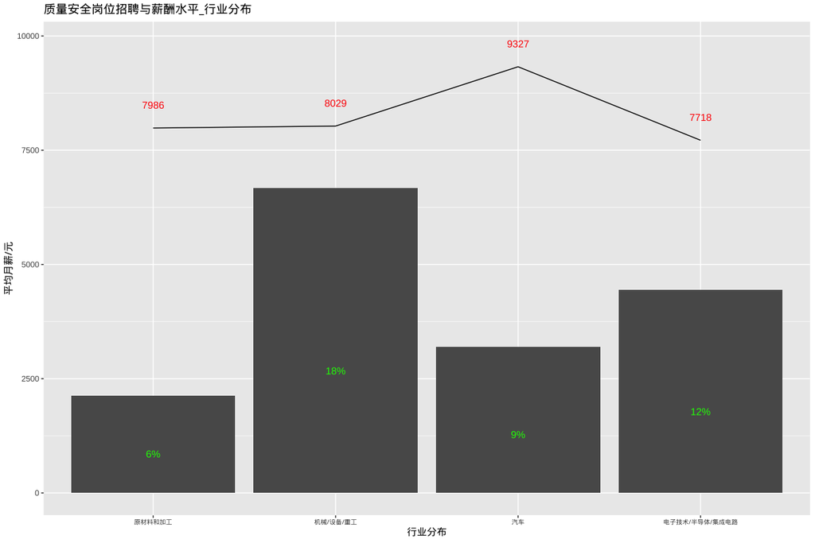

industries

## 03.公司规模

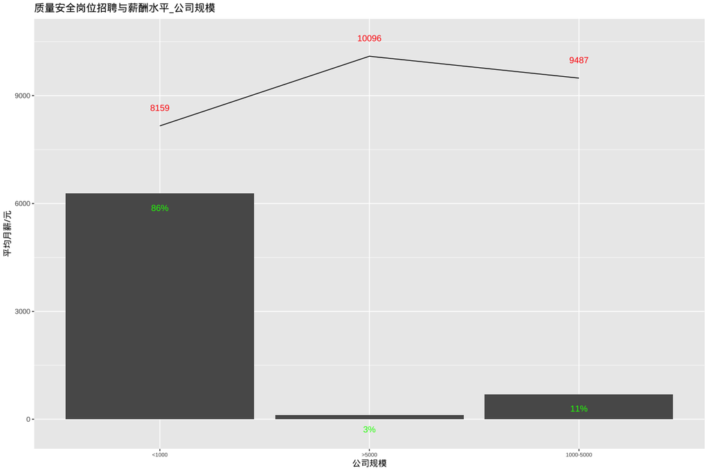

com_size

## 04.公司类型

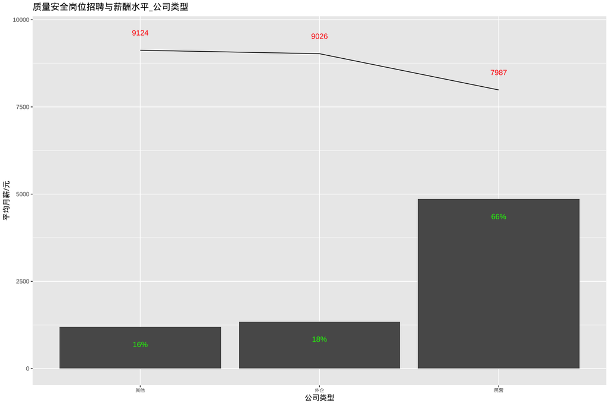

com_type

## 05.工作经验

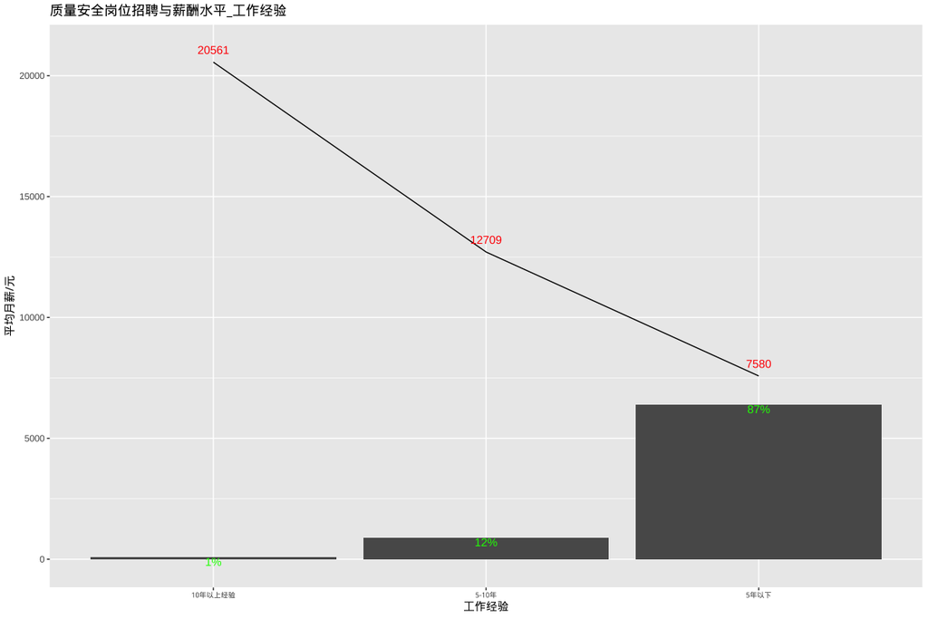

experience

## 06.学历要求

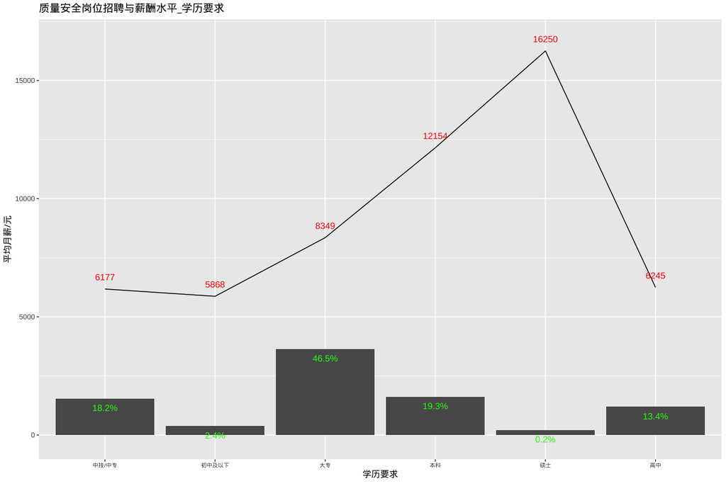

education